# Rules & Tenure Models

double check bc hhtenure wasnt set as factor intd

<Jan 8>

(removed ordering of params except for Rules)

—- Data prep: (hidden in report view)  
< not including Use params in td now >

—* Recode household-level tenure vars:  
Per discussion on Jan 7, have condensed use & possession responses in to one category. See previous versions in version control.

```r
  # Winter Pasture Tenure:
td<- mutate(td, hhTenureWPast = case_when(ContractWPast == 0 ~ 0,   # No contract
                                       ContractWPast == 1 ~ 1,   # Yes use contract
                                       ContractWPast == 2 ~ 1,   # Yes possession contract
                                       TRUE ~ NA_real_))
  # Winter Camp Tenure:
td<- mutate(td, hhTenureWCamp = case_when(ContractWCamp == 0 ~ 0,   # No contract
                                       ContractWCamp == 1 ~ 1,   # Yes use contract
                                       ContractWCamp == 2 ~ 1,   # Yes possession contract
                                       TRUE ~ NA_real_))         # else NA

  # Spring Pasture Tenure:
td<- mutate(td, hhTenureSpPast = case_when(ContractSpPast == 0 ~ 0,   # No contract
                                       ContractSpPast == 1 ~ 1,   # Yes use contract
                                       ContractSpPast == 2 ~ 1,   # Yes possession contract
                                       TRUE ~ NA_real_))         # else NA
  # Spring Camp Tenure:
td<- mutate(td, hhTenureSpCamp = case_when(ContractSpCamp == 0 ~ 0,   # No contract
                                       ContractSpCamp == 1 ~ 1,   # Yes use contract
                                       ContractSpCamp == 2 ~ 1,   # Yes possession contract
                                       TRUE ~ NA_real_))         # else NA

  # order:
#td %<>% mutate_at(20:21, funs(ordered(.)))
td %<>% mutate_at(18:21, funs(factor(.)))
```

— Add dummy Vars for Rules : [this is only useful for a few of the models]

—Another subset of the df that accounts for removal of NAs in Social capital, so can compare across:

```r
td.sc <- td %>% drop_na(cogSC1)
```

# Data exploration and some basic cross-tabs:

# Frequency Tables

mytable <- xtabs(~A_UsWtrCamp+B_ContractWtrCamp, data=td) ftable(mytable) # print table

```r
hh<- xtabs(~td$hhTenureWPast + td$hhTenureWCamp +ez , data = td)
ftable(hh)
```

```
##                                   ez   1   2   3   4
## td$hhTenureWPast td$hhTenureWCamp
## 0                0                    47  10   8  75
##                  1                   119  90   8 112
## 1                0                     0   0   0   0
##                  1                    16  11   7  14
```

```r
summary(hh)
```

```
## Call: xtabs(formula = ~td$hhTenureWPast + td$hhTenureWCamp + ez, data = td)
## Number of cases in table: 517
## Number of factors: 3
## Test for independence of all factors:
##  Chisq = 70.56, df = 10, p-value = 0.00000000003458
##  Chi-squared approximation may be incorrect
```

ot<- xtabs(~ResWint + TenureWPast, data = td) ftable(ot) summary(ot)

rt<- xtabs(~ResWint + hhTenureWPast, data = td) ftable(rt) summary(rt)

relationship btwn social capital on prob of reserving pastures, given diff levels of Rule formality:

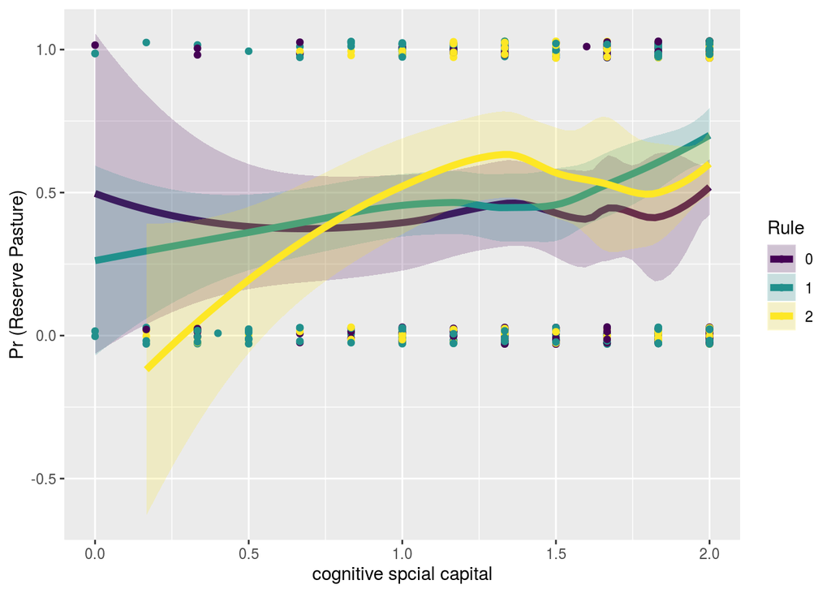

```r
ggplot(td, aes(cogSC1, as.numeric(ResWint)-1, color=Rule)) +
  stat_smooth(method="loess", formula=y~x,
              alpha=0.2, size=2, aes(fill=Rule)) +
  geom_point(position=position_jitter(height=0.03, width=0)) +
  xlab("cognitive spcial capital") + ylab("Pr (Reserve Pasture)")
```

Social capital rel to Reserving pastures across ecological zones.

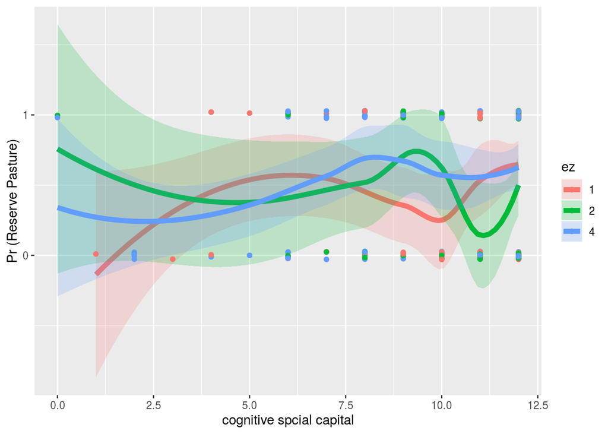

```r
td %>% filter(ez == c(1,2,4)) %>% ggplot(aes(cogSC2, as.numeric(ResWint)-1, color=ez)) +
  stat_smooth(method="loess", formula=y~x,
              alpha=0.2, size=2, aes(fill=ez)) +
  geom_point(position=position_jitter(height=0.03, width=0)) +
  xlab("cognitive spcial capital") + ylab("Pr (Reserve Pasture)")
```

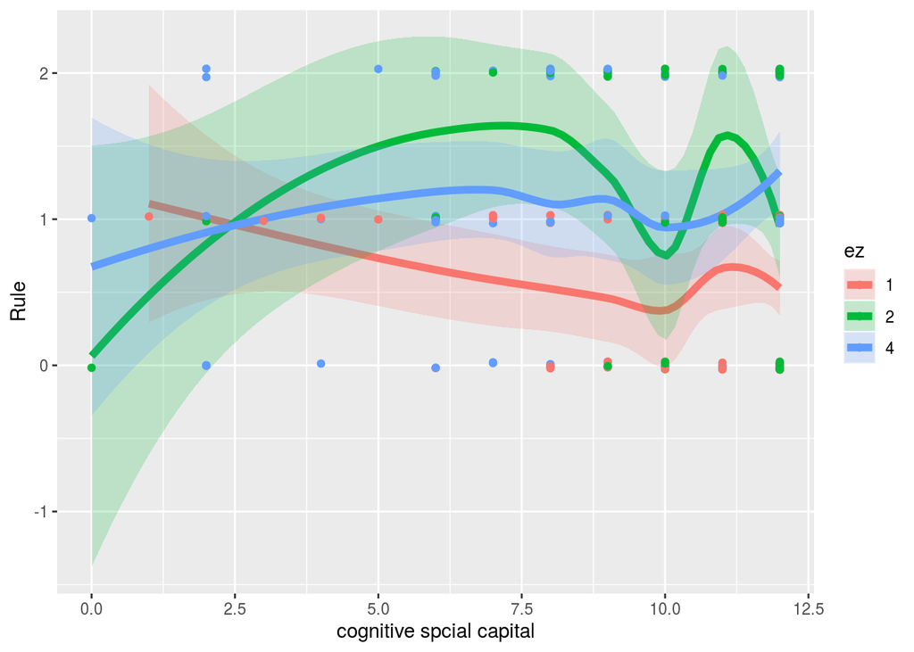

```r
td %>% filter(ez == c(1,2,4)) %>% ggplot(aes(cogSC2, as.numeric(Rule)-1, color=ez)) +
  stat_smooth(method="loess", formula=y~x,
              alpha=0.2, size=2, aes(fill=ez)) +
  geom_point(position=position_jitter(height=0.03, width=0)) +
  xlab("cognitive spcial capital") + ylab("Rule")
```

```r
sr <- xtabs(~ cogSC1 + Rule + ez, data =td)
ftable(sr)
```

```
##                        ez  1  2  3  4
## cogSC1            Rule
## 0                 0        0  1  0  0
##                   1        1  0  0  3
##                   2        0  0  0  0
## 0.166666666666667 0        1  0  0  0
##                   1        1  1  0  2
##                   2        0  0  0  2
## 0.333333333333333 0        0  1  0  5
##                   1        2  0  1  2
##                   2        0  0  0  2
## 0.4               0        0  0  0  0
##                   1        0  1  0  0
##                   2        0  0  0  0
## 0.5               0        0  0  0  0
```

[output cut: 32 more lines]

—Rule formality by response to Reserving Pastures

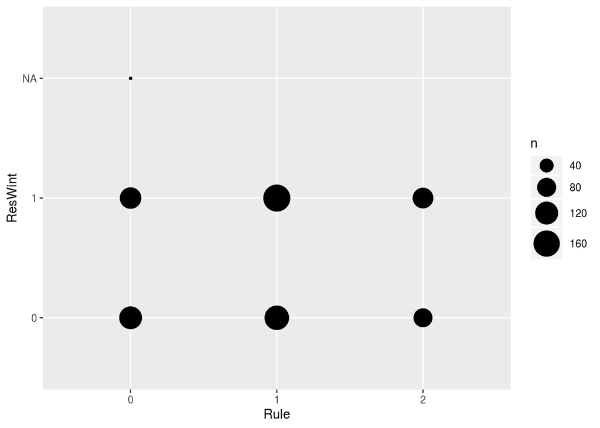

```r
  # Winter Pasture
ggplot(td, aes(x = Rule, y = ResWint)) +
  stat_sum(aes(size = ..n.., group = 1)) +
  scale_size_area(max_size=10)
```

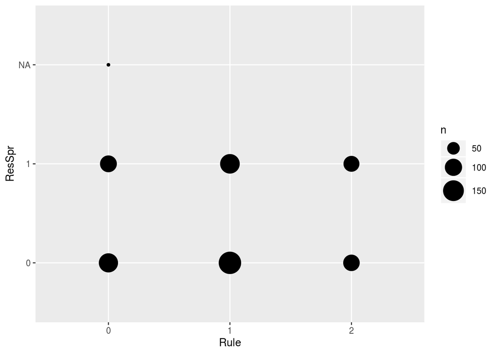

```r
  # Spring Pasture
ggplot(td, aes(x = Rule, y = ResSpr)) +
  stat_sum(aes(size = ..n.., group = 1)) +
  scale_size_area(max_size=10)
```

```r
rc <- xtabs(~ Rule + cbrmYN, data =td)
ftable(rc)
```

```
##      cbrmYN   0   1
## Rule
## 0           153  70
## 1           166 142
## 2             5 170
```

```r
rcez <- xtabs(~ Rule + cbrmYN +ez, data =td)
ftable(rcez)
```

```
##             ez  1  2  3  4
## Rule cbrmYN
## 0    0         38 40 10 65
##      1         62  5  3  0
## 1    0         71 30 20 45
##      1         58 15 15 54
## 2    0          0  0  0  5
##      1          5 65  5 95
```

How correllated are Rule formality and cbrm status? == these are rather correllated, so makes sense that not using both.

```
##
##  Pearson's Chi-squared test
##
## data:  td$Rule and td$cbrmYN
## X-squared = 184.82, df = 2, p-value < 0.00000000000000022
```

# MODELS:

In this doc I am only including the best models thus far. For full information on process of investigating alternate variable forms and model fits see Rules_model.Rmd

# 2. WINTER :

Predicting Likelihood that a herder household will reserve Winter Pastures

where $y_i$ is the dependent variable measured at houhold $i$ in organization $j$. Model 1 was used as the baseline model to estimate the group-level variance in the dependent variable. We compared each model to an intercept-only model and models w random intercepts performed better in both instances. We assessed subsets of the independent/predictor variables via a stepwise method to explore the relative model fits across different combinations of predictors.

[Based on these I am going to just go w Org as grouping var (random) for both w & sp]

```r
nullw  <-  glm ( ResWint ~ 1 , data=td, family=binomial)   # AIC = 977
nullw.r <-  glmer( ResWint ~ 1 + (1|Org), data=td, family=binomial) #AIC = 947.2
nullw.re <-  glmer( ResWint ~ 1 + (1|ez), data=td, family=binomial) #worse
```

```
## boundary (singular) fit: see ?isSingular
```

```r
nullw.rs <-  glmer( ResWint ~ 1 + (1|Soum), data=td, family=binomial) #better
nullw.rso <-  glmer( ResWint ~ 1 + (1|Soum) + (1|Org), data=td, family=binomial)  #best, AIC = 934.4
nullw.rsxo <-  glmer( ResWint ~ 1 + (Org|Soum), data=td, family=binomial)
```

```
## boundary (singular) fit: see ?isSingular
```

```r
anova(nullw, nullw.r, nullw.re, nullw.rs, nullw.rso, nullw.rsxo)
```

```
## Analysis of Deviance Table
##
## Model: binomial, link: logit
##
## Response: ResWint
##
## Terms added sequentially (first to last)
##
##
##      Df Deviance Resid. Df Resid. Dev
## NULL                   704      975.6
```

```r
nulls  <-  glm ( ResSpr ~ 1 , data = td, family = binomial)
nulls.r <-  glmer( ResSpr ~ 1 + (1|Org), data = td, family = binomial) #better
nulls.re <-  glmer( ResSpr ~ 1 + (1|ez), data = td, family = binomial) #worse
nulls.rs <-  glmer( ResSpr ~ 1 + (1|Soum), data = td, family = binomial) #better
nulls.rso <-  glmer( ResSpr ~ 1 + (1|Soum)+ (1|Org), data = td, family = binomial)  #worse
```

```
## boundary (singular) fit: see ?isSingular
```

```r
anova(nulls.r, nulls.re, nulls.rs, nulls.rso)
```

```
## Data: td
## Models:
## nulls.r: ResSpr ~ 1 + (1 | Org)
## nulls.re: ResSpr ~ 1 + (1 | ez)
## nulls.rs: ResSpr ~ 1 + (1 | Soum)
## nulls.rso: ResSpr ~ 1 + (1 | Soum) + (1 | Org)
##           Df    AIC    BIC  logLik deviance  Chisq Chi Df
## nulls.r    2 950.04 959.15 -473.02   946.04
## nulls.re   2 969.88 979.00 -482.94   965.88  0.000      0
## nulls.rs   2 913.65 922.76 -454.82   909.65 56.236      0
## nulls.rso  3 915.65 929.32 -454.82   909.65  0.000      1
##                    Pr(>Chisq)
## nulls.r
## nulls.re                    1
## nulls.rs  <0.0000000000000002 ***
## nulls.rso                   1
## ---
## Signif. codes:  0 '***' 0.001 '**' 0.01 '*' 0.05 '.' 0.1 ' ' 1
```

```r
summary(nullw.r )
```

```
## Generalized linear mixed model fit by maximum likelihood (Laplace
##   Approximation) [glmerMod]
##  Family: binomial  ( logit )
## Formula: ResWint ~ 1 + (1 | Org)
##    Data: td
##
##      AIC      BIC   logLik deviance df.resid
##    947.2    956.3   -471.6    943.2      703
##
## Scaled residuals:
##     Min      1Q  Median      3Q     Max
## -1.5380 -0.9227  0.5466  0.8723  1.5500
##
## Random effects:
##  Groups Name        Variance Std.Dev.
##  Org    (Intercept) 0.9443   0.9717
## Number of obs: 705, groups:  Org, 142
##
## Fixed effects:
##             Estimate Std. Error z value Pr(>|z|)
## (Intercept)   0.1218     0.1168   1.043    0.297
```

```r
summary(nulls.r )
```

```
## Generalized linear mixed model fit by maximum likelihood (Laplace
##   Approximation) [glmerMod]
##  Family: binomial  ( logit )
## Formula: ResSpr ~ 1 + (1 | Org)
##    Data: td
##
##      AIC      BIC   logLik deviance df.resid
##    950.0    959.2   -473.0    946.0      702
##
## Scaled residuals:
##     Min      1Q  Median      3Q     Max
## -1.3892 -0.7522 -0.5757  0.9830  1.4242
##
## Random effects:
##  Groups Name        Variance Std.Dev.
##  Org    (Intercept) 0.6689   0.8178
## Number of obs: 704, groups:  Org, 142
##
## Fixed effects:
##             Estimate Std. Error z value Pr(>|z|)
## (Intercept)  -0.2716     0.1073  -2.532   0.0113 *
## ---
## Signif. codes:  0 '***' 0.001 '**' 0.01 '*' 0.05 '.' 0.1 ' ' 1
```

Ref: http://data.princeton.edu/wws509/R/c3s1.html

####2.2 Winter Pasture Tenure & Rule Formality ** Household level tenure var: **This model uses the response from the Household-level survey regarding whether the hh has a Use or Possession contract for the Winter Pasture. Also incorporated the hh-level Q regarding tenure status on the Winter** CAMPSITE** as a predictor for these models as well. Compared multiple models in original work (Rules_model.Rmd) with different combinations of Rule vars, cbrm status and Social Capital param.

Also, ended up specifying random intercept for Org when using the hh-level Tenure var. Is this signif bc there is Org-level influence on either a) what kind of tenure a hh woudl have and/or b) how much they actually know about their tenure-status? (note: much worse fit if include a random intercept for ez when using hh level tenure var. surprising that this doesn’t vary?)

*Now Rules are more significant than cbrm status.*

[Note jan8: added ordinal Rule para rather than the dummy var Rule/No] Below I have just the results of a stepwise model comparison, based on all of the previous work re: the rel of these params. Stepwise: [Can only do this with model without random intercepts included, but generally the same message if we compare these manually, which I do in a diff doc] In general I don’t want to use this, as it is not theory based, just throwing it all in, but we did lots of testing prior and this was just to check.

```r
fullmod <- glm(ResWint ~ hhTenureWCamp+hhTenureWPast +  Rule + RuleNo+ cbrmYN +cogSC1 +ez , family = binomial,data = td)
backward <- step(fullmod)
```

```
## Start:  AIC=677.8
## ResWint ~ hhTenureWCamp + hhTenureWPast + Rule + RuleNo + cbrmYN +
##     cogSC1 + ez
##
##
## Step:  AIC=677.8
## ResWint ~ hhTenureWCamp + hhTenureWPast + Rule + cbrmYN + cogSC1 +
##     ez
##
##                 Df Deviance    AIC
## - cbrmYN         1   658.07 676.07
## <none>               657.80 677.80
## - hhTenureWCamp  1   661.08 679.08
## - ez             3   665.56 679.56
## - hhTenureWPast  1   662.84 680.84
## - Rule           2   665.57 681.57
## - cogSC1         1   671.43 689.43
##
## Step:  AIC=676.07
## ResWint ~ hhTenureWCamp + hhTenureWPast + Rule + cogSC1 + ez
##
##                 Df Deviance    AIC
## <none>               658.07 676.07
## - ez             3   665.58 677.58
## - hhTenureWCamp  1   661.65 677.65
## - hhTenureWPast  1   663.28 679.28
## - Rule           2   667.91 681.91
## - cogSC1         1   672.16 688.16
```

```r
summary(backward) #gives the best model
```

```
##
## Call:
## glm(formula = ResWint ~ hhTenureWCamp + hhTenureWPast + Rule +
##     cogSC1 + ez, family = binomial, data = td)
##
## Deviance Residuals:
##     Min       1Q   Median       3Q      Max
## -2.3508  -1.1560   0.7884   1.0161   1.8186
##
## Coefficients:
##                Estimate Std. Error z value Pr(>|z|)
## (Intercept)     -1.4116     0.4142  -3.408 0.000655 ***
## hhTenureWCamp1   0.4126     0.2182   1.891 0.058660 .
## hhTenureWPast1   0.8302     0.3804   2.183 0.029066 *
## Rule.L           0.4575     0.1888   2.423 0.015396 *
## Rule.Q          -0.2338     0.1660  -1.408 0.159032
## cogSC1           0.7404     0.2009   3.686 0.000228 ***
## ez2              0.2992     0.2679   1.117 0.264083
## ez3              1.4046     0.5872   2.392 0.016751 *
## ez4              0.1426     0.2355   0.606 0.544758
## ---
## Signif. codes:  0 '***' 0.001 '**' 0.01 '*' 0.05 '.' 0.1 ' ' 1
##
## (Dispersion parameter for binomial family taken to be 1)
##
##     Null deviance: 702.98  on 514  degrees of freedom
## Residual deviance: 658.07  on 506  degrees of freedom
##   (191 observations deleted due to missingness)
## AIC: 676.07
##
## Number of Fisher Scoring iterations: 4
```

####Takeaway: The data are best explained by a model that includes:  
**Tenure on Winter Pasture AND Camp, Rule formality and cognitive social capital.**

BUT this form will not let us take random effects of Organization and/or Soum in to account, and we know from previous steps (see Rules_model.Rmd doc) that model fit improves with including random effect of Org, based on assumption that there may be more sim within group that among.

So, this is the same model as above, but w random effects of Org specified. Modelling with BOTH winter tenure parameters : Various attempts at models w ecological zone included as either fixed or random effect were not signif and/or performed poorly. Only ez3=Eastern Steppe was ever signif.

```r
#
#htm7 <- glmer(ResWint ~ hhTenureWPast + hhTenureWCamp + Rule + cbrmYN+ cogSC1 +   (1|Org) , family = binomial, data = td.sc)

htm7 <- glmer(ResWint ~ hhTenureWPast + hhTenureWCamp + Rule +  cogSC1 +   (1|Org) , family = binomial, data = td.sc)
summary(htm7)
```

```
## Generalized linear mixed model fit by maximum likelihood (Laplace
##   Approximation) [glmerMod]
##  Family: binomial  ( logit )
## Formula: ResWint ~ hhTenureWPast + hhTenureWCamp + Rule + cogSC1 + (1 |
##     Org)
##    Data: td.sc
##
##      AIC      BIC   logLik deviance df.resid
##    648.5    678.3   -317.3    634.5      508
##
## Scaled residuals:
##     Min      1Q  Median      3Q     Max
## -2.3330 -0.7309  0.3606  0.6583  1.8599
##
## Random effects:
##  Groups Name        Variance Std.Dev.
##  Org    (Intercept) 1.478    1.216
## Number of obs: 515, groups:  Org, 139
##
## Fixed effects:
##                Estimate Std. Error z value Pr(>|z|)
## (Intercept)     -1.4752     0.4715  -3.129 0.001756 **
## hhTenureWPast1   0.8521     0.4422   1.927 0.053988 .
## hhTenureWCamp1   0.6313     0.2842   2.222 0.026309 *
## Rule.L           0.6244     0.2904   2.150 0.031521 *
## Rule.Q          -0.3526     0.2593  -1.360 0.173921
## cogSC1           0.8847     0.2567   3.447 0.000567 ***
## ---
## Signif. codes:  0 '***' 0.001 '**' 0.01 '*' 0.05 '.' 0.1 ' ' 1
##
## Correlation of Fixed Effects:
##             (Intr) hhTWP1 hhTWC1 Rule.L Rule.Q
## hhTenrWPst1 -0.047
## hhTenrWCmp1 -0.366 -0.186
## Rule.L       0.036  0.045 -0.066
## Rule.Q       0.227 -0.067 -0.052  0.117
## cogSC1      -0.843  0.059 -0.050  0.069 -0.170
```

```r
tab_model(htm7)
```

|  | ResWint |  |  |
| --- | --- | --- | --- |
| Predictors | Odds Ratios | CI | p |
| (Intercept) | 0.23 | 0.09 – 0.58 | **0.002** |
| hhTenureWPast1 | 2.34 | 0.99 – 5.58 | 0.054 |
| hhTenureWCamp1 | 1.88 | 1.08 – 3.28 | **0.026** |
| Rule.L | 1.87 | 1.06 – 3.30 | **0.032** |
| Rule.Q | 0.70 | 0.42 – 1.17 | 0.174 |
| cogSC1 | 2.42 | 1.46 – 4.01 | **0.001** |
| Random Effects |  |  |  |
| σ<sup>2</sup> | 3.29 |  |  |
| τ<sub>00</sub> <sub>Org</sub> | 1.48 |  |  |
| ICC | 0.31 |  |  |
| N <sub>Org</sub> | 139 |  |  |
| Observations | 515 |  |  |
| Marginal R<sup>2</sup> / Conditional R<sup>2</sup> | 0.098 / 0.377 |  |  |

```r
wchi.diff<- (943.16-634.54)
wdf.diff<- (703-508)
pchisq(wchi.diff, wdf.diff, lower.tail = F)
```

```
## [1] 0.0000003888938
```

**Can also look at the outputs as odds ratios:** which I find slightly easier to interpret.  
Based on htm7:

But, the Marginal R^2 is very low….

```r
tab_model(htm7)
```

|  | ResWint |  |  |
| --- | --- | --- | --- |
| Predictors | Odds Ratios | CI | p |
| (Intercept) | 0.23 | 0.09 – 0.58 | **0.002** |
| hhTenureWPast1 | 2.34 | 0.99 – 5.58 | 0.054 |
| hhTenureWCamp1 | 1.88 | 1.08 – 3.28 | **0.026** |
| Rule.L | 1.87 | 1.06 – 3.30 | **0.032** |
| Rule.Q | 0.70 | 0.42 – 1.17 | 0.174 |
| cogSC1 | 2.42 | 1.46 – 4.01 | **0.001** |
| Random Effects |  |  |  |
| σ<sup>2</sup> | 3.29 |  |  |
| τ<sub>00</sub> <sub>Org</sub> | 1.48 |  |  |
| ICC | 0.31 |  |  |
| N <sub>Org</sub> | 139 |  |  |
| Observations | 515 |  |  |
| Marginal R<sup>2</sup> / Conditional R<sup>2</sup> | 0.098 / 0.377 |  |  |

The odds of a hh reserving winter pasture are lower if there are not Rules in place regarding timing of grazing of (winter pasture). However, the odds of the hh reserving pasture increase with increasing tenure on the winter camp. The odds of the household reserving pasture increases the most with increases in Social Capital.  
The conditional R2 describes the proportion of variance explained by both the fixed and random factors morginal is just fixed factors.

But, while we can run the full models w random effect by Org specified and extract those coeffs (see above work) that **doesn’t get us differences by ez which might be important,** and the models won’t run w random effect by ez also included (won’t converge)[this may be bc of issues revealed in the Steppe-only model below?] [Seeking help on this from another person]

So, maybe we look at these separately then. -either by ecological zone separately to see if diff models needed for diff zones. AND/or -to assess the relative impacts of Rules across the zones.

In the meantime, here’s the original and predicted values. To visualize will have to decide a cut-off point for the fitted to assign 0/1

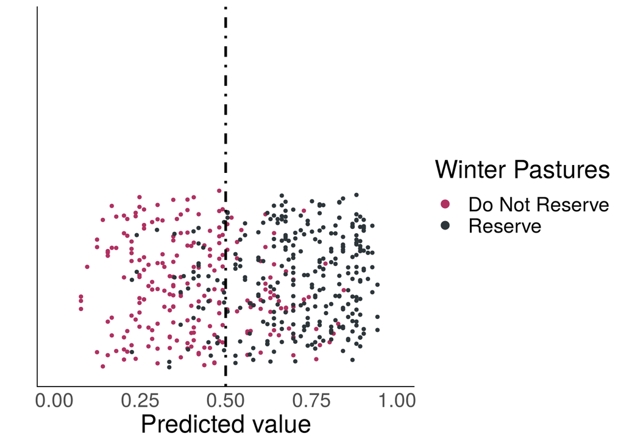

```r
df.htm7<- htm7@frame
wDat <- data.frame(htm7@frame, resid=residuals(htm7,type="pearson"),fitted=fitted(htm7))

theme= theme(panel.grid.major = element_blank(),
             panel.grid.minor = element_blank(),
             panel.background = element_blank(),
             axis.text.y = element_blank(),
             axis.ticks = element_blank(),
             axis.line.x = element_line(color = "black"),
             axis.line.y = element_line(color = "black"),
             text = element_text(size = 20),
             legend.key = element_blank())
hist <- ggplot(wDat, aes(fitted, color = ResWint, fill = ResWint))
hist +
  theme +
  geom_dotplot(binwidth = 0.01, position = "jitter")+
  coord_cartesian(xlim = c(0,1))+
  xlab("Predicted value")+
  ylab(" ")+
  scale_color_manual(values = c("Maroon", "#2C3539"), #change
                     labels = c("Do Not Reserve", "Reserve"),
                     name = "Winter Pastures")+
  scale_fill_manual(values = c("Maroon", "#2C3539"), #change
                     labels = c("Do Not Reserve", "Reserve"),
                     name = "Winter Pastures")+
  geom_vline(xintercept = c(0.5), linetype = "dotdash", size = 1)
```

Let’s explore the values w high predicted value but observed = 0 to see what’s up.

```r
# filter the df of predicted vals it so it's the values on the right that were obsv No, pred Yes and look at summary stats:
wDat%>%dplyr::filter(fitted >= 0.5) %>% filter(ResWint == 0) %>% summary_table(.)
```

```
##
## \begin{tabular}{l|l}
## \hline
##  & . (N = 57)\\
## \hline
## \bf{ResWint} & ~\\
## \hline
## ~~ 0 & 57 (100)\\
## \hline
## ~~ 1 & 0 (0)\\
## \hline
## \bf{hhTenureWPast} & ~\\
## \hline
## ~~ 0 & 49 (86)\\
## \hline
## ~~ 1 & 8 (14)\\
## \hline
## \bf{hhTenureWCamp} & ~\\
## \hline
## ~~ 0 & 6 (11)\\
## \hline
## ~~ 1 & 51 (89)\\
## \hline
## \bf{Rule} & ~\\
## \hline
## ~~ 0 & 18 (32)\\
## \hline
## ~~ 1 & 24 (42)\\
## \hline
## ~~ 2 & 15 (26)\\
## \hline
## \bf{cogSC1} & ~\\
## \hline
## ~~ minimum & 0.67\\
## \hline
## ~~ median (IQR) & 2.00 (1.50, 2.00)\\
## \hline
## ~~ mean (sd) & 1.75 $\pm$ 0.35\\
## \hline
## ~~ maximum & 2.00\\
```

[output cut: 17 more lines]

```
## ~~ mean (sd) & -1.39 $\pm$ 0.31\\
## \hline
## ~~ maximum & -1.00\\
## \hline
## \bf{fitted} & ~\\
## \hline
## ~~ minimum & 0.50\\
## \hline
## ~~ median (IQR) & 0.63 (0.57, 0.70)\\
## \hline
## ~~ mean (sd) & 0.64 $\pm$ 0.09\\
## \hline
## ~~ maximum & 0.84\\
## \hline
## \end{tabular}
```

```r
badpred <- wDat%>%dplyr::filter(fitted >= 0.5) %>% filter(ResWint == 0)
# let's compare those to the summary stats for the correctly predicted:
wDat%>%dplyr::filter(fitted >= 0.5) %>% filter(ResWint == 1) %>% summary_table(.)
```

```
##
## \begin{tabular}{l|l}
## \hline
##  & . (N = 255)\\
## \hline
## \bf{ResWint} & ~\\
## \hline
## ~~ 0 & 0 (0)\\
## \hline
## ~~ 1 & 255 (100)\\
## \hline
## \bf{hhTenureWPast} & ~\\
## \hline
## ~~ 0 & 220 (86)\\
## \hline
## ~~ 1 & 35 (14)\\
## \hline
## \bf{hhTenureWCamp} & ~\\
## \hline
## ~~ 0 & 43 (17)\\
## \hline
## ~~ 1 & 212 (83)\\
## \hline
## \bf{Rule} & ~\\
## \hline
## ~~ 0 & 64 (25)\\
## \hline
## ~~ 1 & 114 (45)\\
## \hline
## ~~ 2 & 77 (30)\\
## \hline
## \bf{cogSC1} & ~\\
## \hline
## ~~ minimum & 0.17\\
## \hline
## ~~ median (IQR) & 1.83 (1.50, 2.00)\\
## \hline
## ~~ mean (sd) & 1.70 $\pm$ 0.39\\
## \hline
## ~~ maximum & 2.00\\
```

[output cut: 17 more lines]

```
## ~~ mean (sd) & 0.57 $\pm$ 0.19\\
## \hline
## ~~ maximum & 1.00\\
## \hline
## \bf{fitted} & ~\\
## \hline
## ~~ minimum & 0.50\\
## \hline
## ~~ median (IQR) & 0.77 (0.67, 0.86)\\
## \hline
## ~~ mean (sd) & 0.75 $\pm$ 0.11\\
## \hline
## ~~ maximum & 0.95\\
## \hline
## \end{tabular}
```

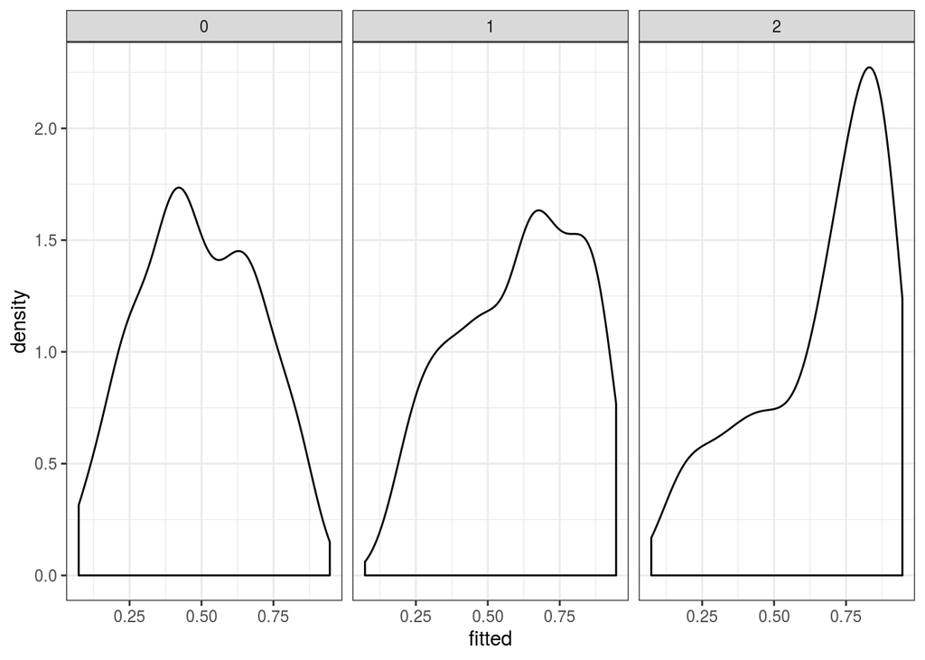

```r
# merge w the original data so can visualize by EZ:

#wDat.td<- left_join(wDat, td, by = "Org")


ggplot(wDat, aes(fitted))+geom_density()+facet_wrap(.~Rule)+theme_bw()
```

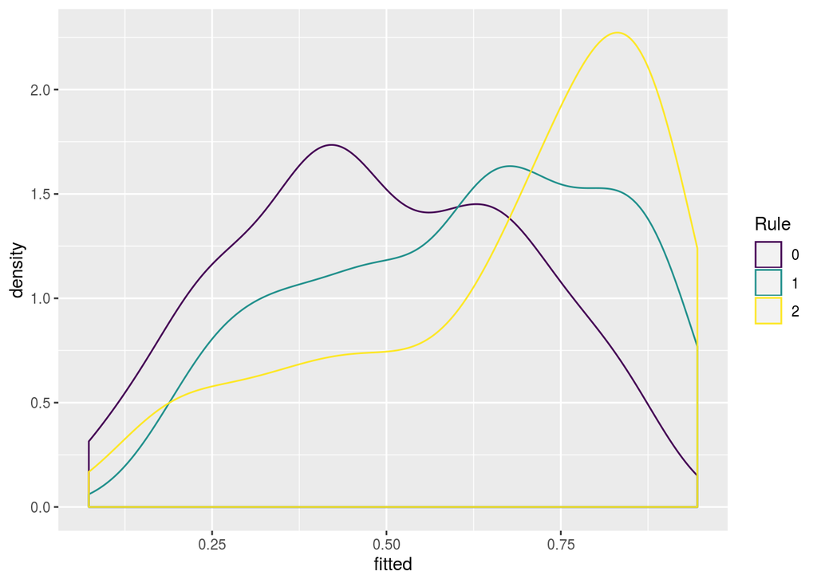

```r
# histogram of predicted values, colored by Rule formality
ggplot(wDat, aes(fitted, color= Rule)) + geom_density()
```

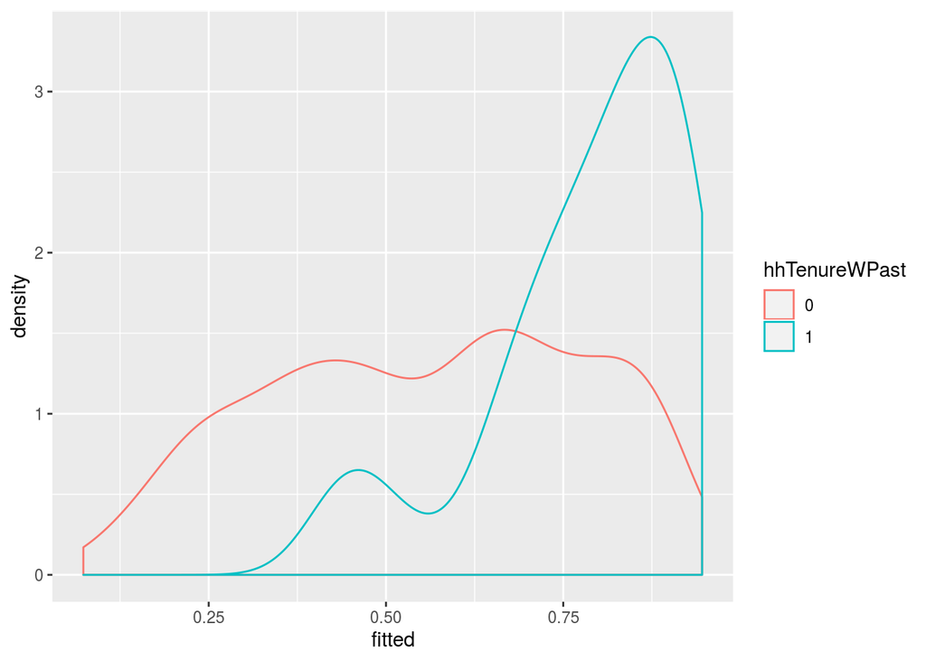

```r
ggplot(wDat, aes(fitted, color= hhTenureWPast)) + geom_density()
```

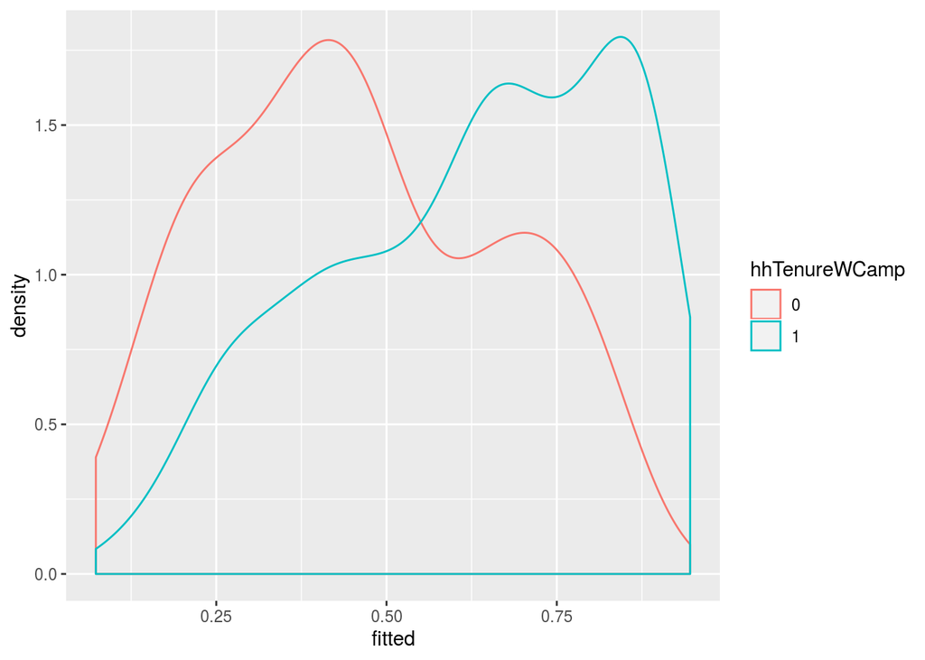

```r
ggplot(wDat, aes(fitted, color= hhTenureWCamp)) + geom_density()
```

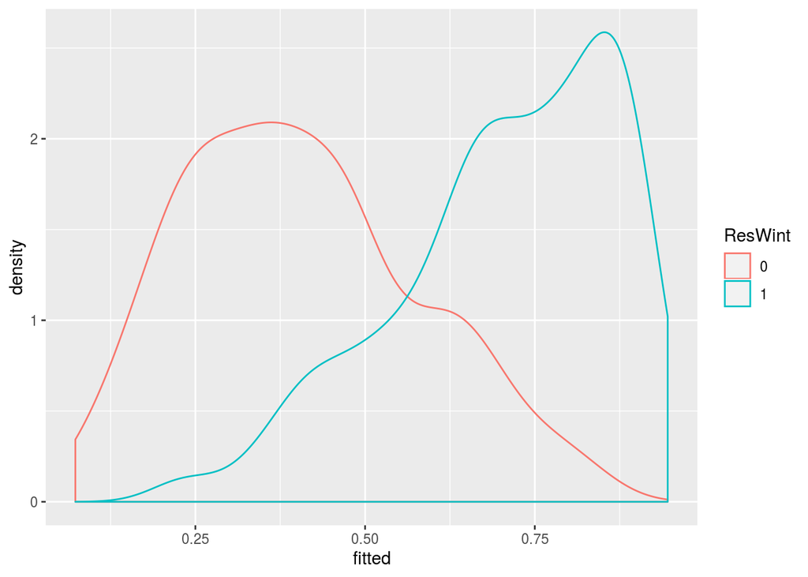

```r
ggplot(wDat, aes(fitted, color= ResWint)) + geom_density()
```

——# **Reserve Spring Pastures**

Do we see similar relationships with potential explanatory variables?  
nullSp<- glm( ResSpr ~1, data= td, family = binomial)  
This only works when we use the dummary variable version of the Rules var: RuleNo or RuleInf both work w basically same result. Again, not using the Org-level tenure var anymore.

```r
 ## Sp Pasture, household level tenure var:
htmSp <- glmer(ResSpr ~ hhTenureSpPast + cbrmYN + RuleNo + cogSC1 + (1|Org) , family = binomial, data = td ) # hmmmm.... now cbrm signif
summary(htmSp)
```

```
## Generalized linear mixed model fit by maximum likelihood (Laplace
##   Approximation) [glmerMod]
##  Family: binomial  ( logit )
## Formula: ResSpr ~ hhTenureSpPast + cbrmYN + RuleNo + cogSC1 + (1 | Org)
##    Data: td
##
##      AIC      BIC   logLik deviance df.resid
##    593.9    618.5   -291.0    581.9      441
##
## Scaled residuals:
##     Min      1Q  Median      3Q     Max
## -2.3506 -0.8160  0.3442  0.8142  1.8441
##
## Random effects:
##  Groups Name        Variance Std.Dev.
##  Org    (Intercept) 0.5242   0.7241
## Number of obs: 447, groups:  Org, 136
##
## Fixed effects:
##                 Estimate Std. Error z value Pr(>|z|)
## (Intercept)     -1.46936    0.41011  -3.583  0.00034 ***
## hhTenureSpPast1  1.17629    0.44900   2.620  0.00880 **
## cbrmYN1          0.61951    0.26028   2.380  0.01730 *
## RuleNo1         -0.08813    0.27254  -0.323  0.74643
## cogSC1           0.70219    0.23284   3.016  0.00256 **
## ---
## Signif. codes:  0 '***' 0.001 '**' 0.01 '*' 0.05 '.' 0.1 ' ' 1
##
## Correlation of Fixed Effects:
##             (Intr) hhTSP1 cbrYN1 RuleN1
## hhTnrSpPst1 -0.124
## cbrmYN1     -0.294  0.021
## RuleNo1     -0.186 -0.049  0.290
## cogSC1      -0.839  0.060 -0.112 -0.152
```

Double checking model fit with a stepwise procedure confirms (without the random effects) the significance of:  
**Household tenure on the Spring Pasture, *cbrm status* and cognitive social capital.**

```r
fullSpmod <- glm(ResSpr ~ hhTenureSpPast+ hhTenureSpCamp+ Rule + RuleNo+ cbrmYN +cogSC1 , family = binomial,data = td.sc)
backward <- step(fullSpmod)
```

```
## Start:  AIC=540.2
## ResSpr ~ hhTenureSpPast + hhTenureSpCamp + Rule + RuleNo + cbrmYN +
##     cogSC1
##
##
## Step:  AIC=540.2
## ResSpr ~ hhTenureSpPast + hhTenureSpCamp + Rule + cbrmYN + cogSC1
##
##                  Df Deviance    AIC
## - Rule            2   528.84 538.84
## <none>                526.20 540.20
## - cbrmYN          1   528.38 540.38
## - hhTenureSpPast  1   531.49 543.49
## - hhTenureSpCamp  1   532.53 544.53
## - cogSC1          1   536.24 548.24
##
## Step:  AIC=538.84
## ResSpr ~ hhTenureSpPast + hhTenureSpCamp + cbrmYN + cogSC1
##
##                  Df Deviance    AIC
## <none>                528.84 538.84
## - hhTenureSpPast  1   533.77 541.77
## - cbrmYN          1   535.51 543.51
## - hhTenureSpCamp  1   535.92 543.92
## - cogSC1          1   538.63 546.63
```

```r
summary(backward) #gives the best model
```

```
##
## Call:
## glm(formula = ResSpr ~ hhTenureSpPast + hhTenureSpCamp + cbrmYN +
##     cogSC1, family = binomial, data = td.sc)
##
## Deviance Residuals:
##      Min        1Q    Median        3Q       Max
## -1.92897  -1.03345   0.00095   1.09955   1.93209
##
## Coefficients:
##                 Estimate Std. Error z value  Pr(>|z|)
## (Intercept)      -1.6985     0.3850  -4.412 0.0000102 ***
## hhTenureSpPast1   0.9354     0.4425   2.114   0.03453 *
## hhTenureSpCamp1   0.5700     0.2147   2.654   0.00795 **
## cbrmYN1           0.5426     0.2105   2.577   0.00996 **
## cogSC1            0.6709     0.2200   3.050   0.00229 **
## ---
## Signif. codes:  0 '***' 0.001 '**' 0.01 '*' 0.05 '.' 0.1 ' ' 1
##
## (Dispersion parameter for binomial family taken to be 1)
##
##     Null deviance: 568.38  on 409  degrees of freedom
## Residual deviance: 528.84  on 405  degrees of freedom
##   (294 observations deleted due to missingness)
## AIC: 538.84
##
## Number of Fisher Scoring iterations: 4
```

```r
bestSp <- glmer(formula = ResSpr ~ hhTenureSpPast + hhTenureSpCamp+ cbrmYN + RuleNo+ cogSC1 + (1|Org), family = binomial,
    data = td)
tab_model(bestSp)
```

|  | ResSpr |  |  |
| --- | --- | --- | --- |
| Predictors | Odds Ratios | CI | p |
| (Intercept) | 0.16 | 0.07 – 0.40 | **<0.001** |
| hhTenureSpPast1 | 2.49 | 0.95 – 6.56 | 0.064 |
| hhTenureSpCamp1 | 1.91 | 1.16 – 3.16 | **0.011** |
| cbrmYN1 | 1.73 | 1.00 – 3.00 | **0.049** |
| RuleNo1 | 0.84 | 0.47 – 1.50 | 0.559 |
| cogSC1 | 2.15 | 1.30 – 3.55 | **0.003** |
| Random Effects |  |  |  |
| σ<sup>2</sup> | 3.29 |  |  |
| τ<sub>00</sub> <sub>Org</sub> | 0.62 |  |  |
| ICC | 0.16 |  |  |
| N <sub>Org</sub> | 131 |  |  |
| Observations | 410 |  |  |
| Marginal R<sup>2</sup> / Conditional R<sup>2</sup> | 0.121 / 0.260 |  |  |

**Interpretting the odds ratios:** tenure on the spring pasture, membership in a formal CBRM and cognitive social capital all increase the odds that a household will reserve the spring pastures. Rules (re: timing of grazing) were not significant, but the coeffs indicate that the negative impact of NOT having rules on the odds of reserving pasture.. Conditional R2 describes the proportion of variance explained by both the fixed and random factors … which, doesn’t seem great? In the meantime, here’s the original and predicted values. To visualize will have to decide a cut-off point for the fitted to assign 0/1

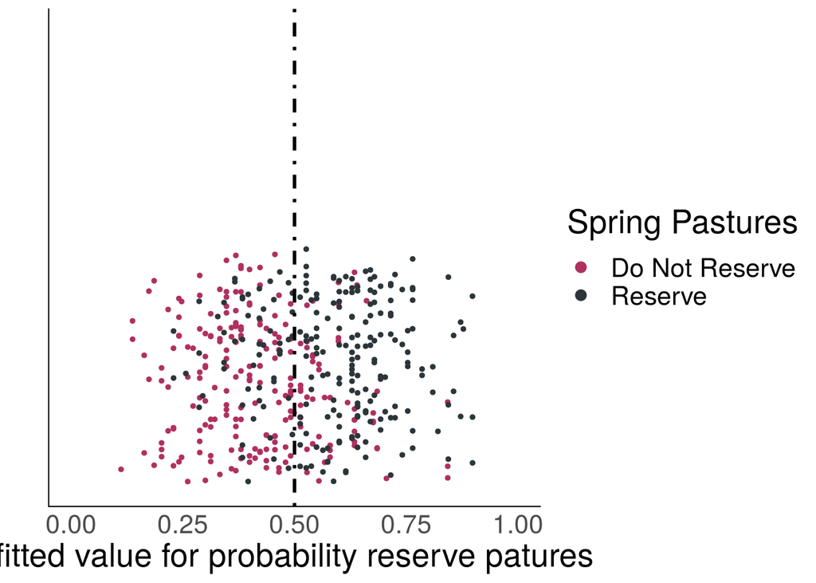

```r
df.htmSp<- htmSp@frame
spDat <- data.frame(htmSp@frame, resid=residuals(htmSp,type="pearson"),fitted=fitted(htmSp))

theme= theme(panel.grid.major = element_blank(),
             panel.grid.minor = element_blank(),
             panel.background = element_blank(),
             axis.text.y = element_blank(),
             axis.ticks = element_blank(),
             axis.line.x = element_line(color = "black"),
             axis.line.y = element_line(color = "black"),
             text = element_text(size = 20),
             legend.key = element_blank())
hist = ggplot(spDat, aes(fitted, color = ResSpr, fill = ResSpr))
hist +
  theme +
  geom_dotplot(binwidth = 0.01, position = "jitter")+
  coord_cartesian(xlim = c(0,1))+
  xlab("fitted value for probability reserve patures")+
  ylab(" ")+
  scale_color_manual(values = c("Maroon", "#2C3539"), #change
                     labels = c("Do Not Reserve", "Reserve"),
                     name = "Spring Pastures")+
  scale_fill_manual(values = c("Maroon", "#2C3539"), #change
                     labels = c("Do Not Reserve", "Reserve"),
                     name = "Spring Pastures")+
  geom_vline(xintercept = c(0.5), linetype = "dotdash", size = 1)
```

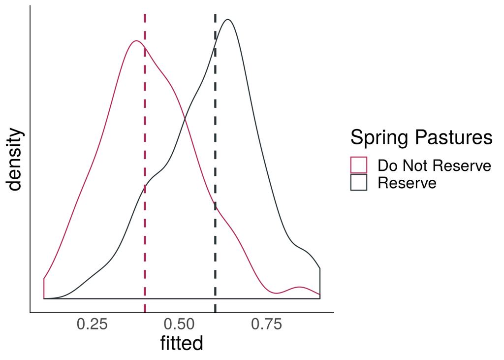

```r
ggplot(spDat, aes(fitted, color= ResSpr)) + geom_density() +
  scale_color_manual(values = c("Maroon", "#2C3539"), #change
                     labels = c("Do Not Reserve", "Reserve"),
                     name = "Spring Pastures")+
  scale_fill_manual(values = c("Maroon", "#2C3539"), #change
                     labels = c("Do Not Reserve", "Reserve"),
                     name = "Spring Pastures")+
  geom_vline(data= filter(spDat, ResSpr == 1), aes(xintercept=median(fitted, na.rm=T)),
               color="#2C3539", linetype="dashed", size=1)+
  geom_vline(data= filter(spDat, ResSpr == 0), aes(xintercept=median(fitted, na.rm=T)),
               color="Maroon", linetype="dashed", size=1)+
  theme
```

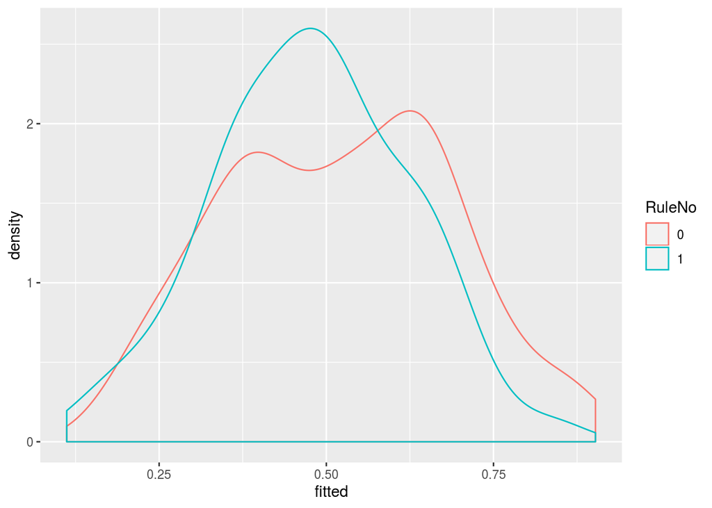

```r
# histogram of predicted values, colored by Rule formality
ggplot(spDat, aes(fitted, color= RuleNo)) + geom_density()
```

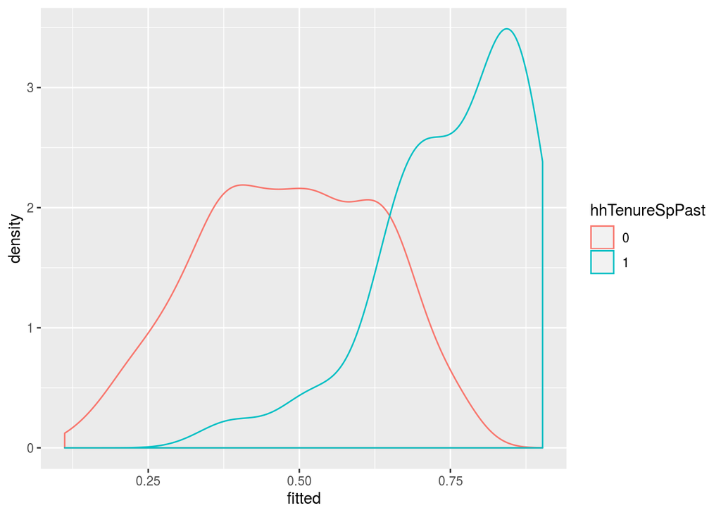

```r
ggplot(spDat, aes(fitted, color= hhTenureSpPast)) + geom_density()
```

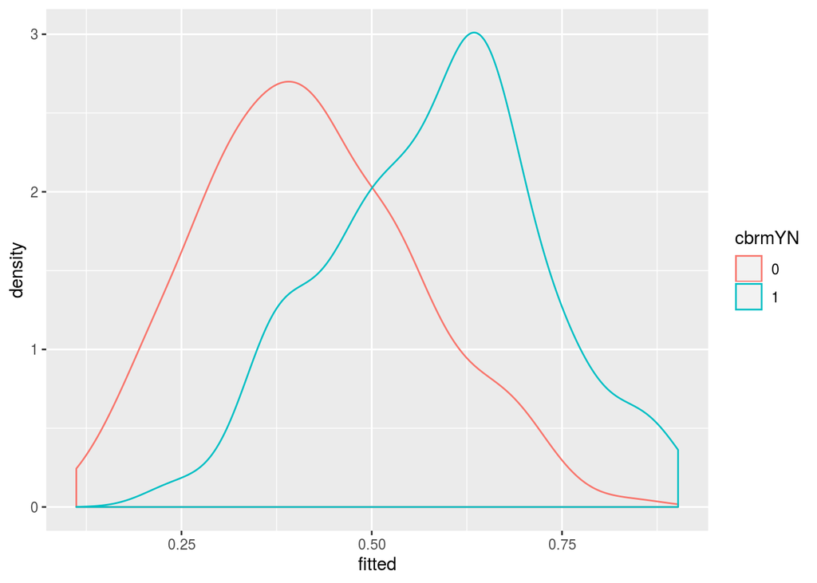

```r
ggplot(spDat, aes(fitted, color= cbrmYN)) + geom_density()
```

### SOCIAL CAPITAL & RULES …

Given what we see above wrt the (weak) relationship between (this particular set of) Rules and (this one) Practice, does this mean for our hypothesized relationships between Social Capital and the prevalance of Informal vs. Formal Rules? Does it vary by TYPE of pasture/season under consideration? Stronger relationship between rule formality and social capital for the Winter pastures compared to Spring pastures.

```r
library(MASS)
# need to use MASS::polr for ordered logistic regression
ezm<- polr(Rule ~ ez, data = td, method = c("logistic"))
scm<- polr(Rule ~ cogSC1 , data = td, method = c("logistic"))
scm1<- polr(Rule ~ cogSC1 + ez, data = td, method = c("logistic"))

anova(scm, scm1) # big improvement by including ez, as we predicted
```

```
## Likelihood ratio tests of ordinal regression models
##
## Response: Rule
##         Model Resid. df Resid. Dev   Test    Df LR stat.
## 1      cogSC1       701   1507.275
## 2 cogSC1 + ez       698   1434.891 1 vs 2     3 72.38373
##                   Pr(Chi)
## 1
## 2 0.000000000000001332268
```

```r
summary(scm1) # outputs are re: prob of being in that class or lower
```

```
## Call:
## polr(formula = Rule ~ cogSC1 + ez, data = td, method = c("logistic"))
##
## Coefficients:
##           Value Std. Error t value
## cogSC1 -0.05768     0.1481 -0.3895
## ez2     1.33078     0.2043  6.5139
## ez3     0.60531     0.2698  2.2435
## ez4     1.30800     0.1752  7.4653
##
## Intercepts:
##     Value   Std. Error t value
## 0|1 -0.1693  0.2708    -0.6251
## 1|2  1.8858  0.2816     6.6981
##
## Residual Deviance: 1434.891
## AIC: 1446.891
## (2 observations deleted due to missingness)
```

```r
#intercepts are the zetas

fit.scm<- scm1$fitted.values
colnames(fit.scm)<- c("None", "Informal", "Formal")
scm.df<- data.frame(fit.scm, scm1$model)

# returns predicted class membership, so look for the highest estimated probability in each zone.
predict(ezm, newdata = data.frame(ez="1"),type="p") #0 = No rules, Inf next
```

```
##         0         1         2
## 0.4850421 0.3950002 0.1199577
```

```r
predict(ezm, newdata = data.frame(ez="2"),type="p") #1 = Inf, formal next
```

```
##         0         1         2
## 0.1972423 0.4595564 0.3432013
```

```r
predict(ezm, newdata = data.frame(ez="3"),type="p") #1 = Inf, then no, then formal
```

```
##         0         1         2
## 0.3355724 0.4617419 0.2026857
```

```r
predict(ezm, newdata = data.frame(ez="4"),type="p") #1 = Inf, then formal next
```

```
##        0        1        2
## 0.199372 0.460440 0.340188
```

```r
# calc cumulative probabilities of having certain rule formality:
exp(ezm$zeta - ezm$coefficients)/(1 + exp(ezm$zeta - ezm$coefficients))
```

```
##       ez2       ez3       ez4
## 0.1972423 0.7973143 0.1993720
```

[figure not shown]

```r
ggplot(scm.df, aes(x=))
```

Big improvement by including ez, as we predicted

**Separating out the data by ecological zone** to try to understand why having issues trying to incorporate ez:  
td by ez

```r
mfs <- td %>% filter(ez == 4)%>% drop_na()
ds  <- td.sc %>% filter(ez == 1)%>% drop_na()
st  <- td.sc %>% filter(ez == 2) %>% drop_na()
```

Now separate models for each ez

1st: Rules by EZ:

```r
# singular fit warning, but does yield diff coefficients for Rules by ez....
mtez<- glmer(ResWint ~ Rule + (1+ Rule|ez), family = binomial,data = td)
```

```
## boundary (singular) fit: see ?isSingular
```

```r
coef(mtez)
```

```
## $ez
##   (Intercept)     Rule.L      Rule.Q
## 1  0.11948123 0.04711624 -0.28667475
## 2  0.07326816 0.16145672 -0.18890402
## 3  0.12355370 0.03704011 -0.29529069
## 4 -0.02398253 0.40207459  0.01684449
##
## attr(,"class")
## [1] "coef.mer"
```

Now separate models for each ez… based on the full models above: htm7 <- glmer(ResWint ~ hhTenureWPast + hhTenureWCamp + Rule + cbrmYN+ cogSC1 + (1|Org) , family = binomial, data = td.sc) htmSp <- glmer(ResSpr ~ hhTenureSpPast + cbrmYN + RuleNo + cogSC1 + (1|Org) , family = binomial, data = td )

**This isn’t working out**  
So i’m hiding it for now. None fitting? Intercept only models best for DS and ST?  
And social capital the only signif param in FMS?

more histograms of params divided out by EZ:

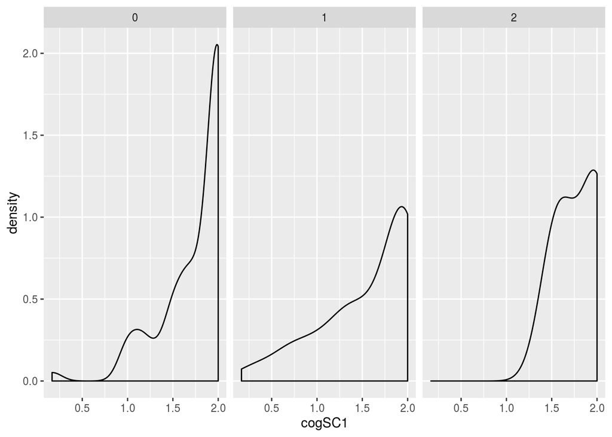

```r
ggplot(ds, aes(cogSC1))+geom_density()+facet_grid(.~Rule)
```

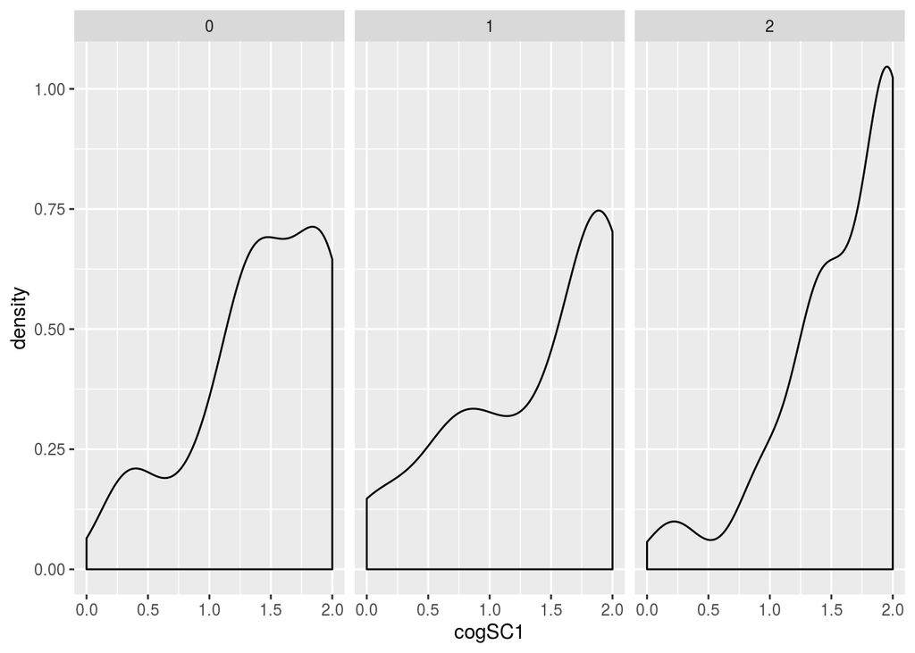

```r
ggplot(mfs, aes(cogSC1))+geom_density()+facet_grid(.~Rule)
```

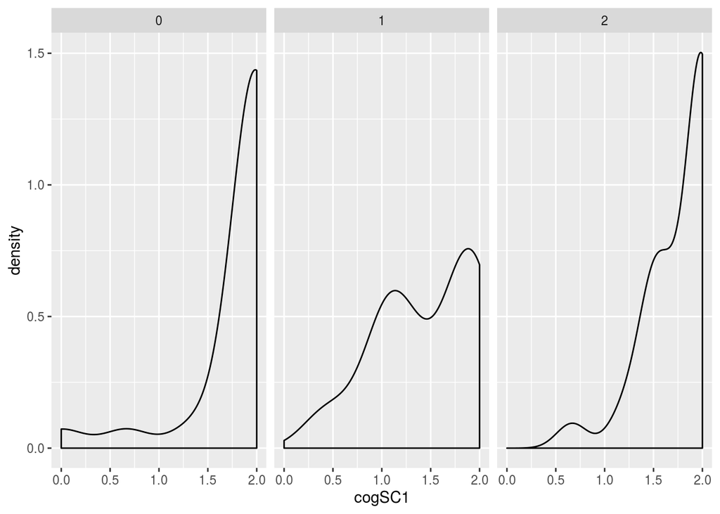

```r
ggplot(st, aes(cogSC1))+geom_density()+facet_grid(.~Rule)
```

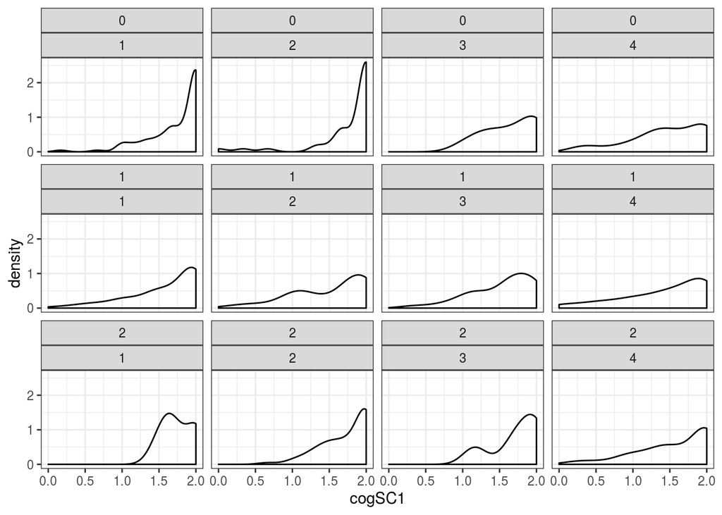

```r
ggplot(td, aes(cogSC1))+geom_density()+facet_wrap(.~Rule*ez)+theme_bw()
```

## ALSO NEED TO LOOK AT PREDICTED VALUES/DISTRIBUTIONS:

Our goal here is to calculate a predicted probability of Reserving Winter Pastures, for specific values of the predictors: Tenure = 1 Rules = 1 vs. 2 cogSC1 continuous values…. To do that, create a dataframe w the specified values: But we’ll need to consider all combinations in order to really predict.

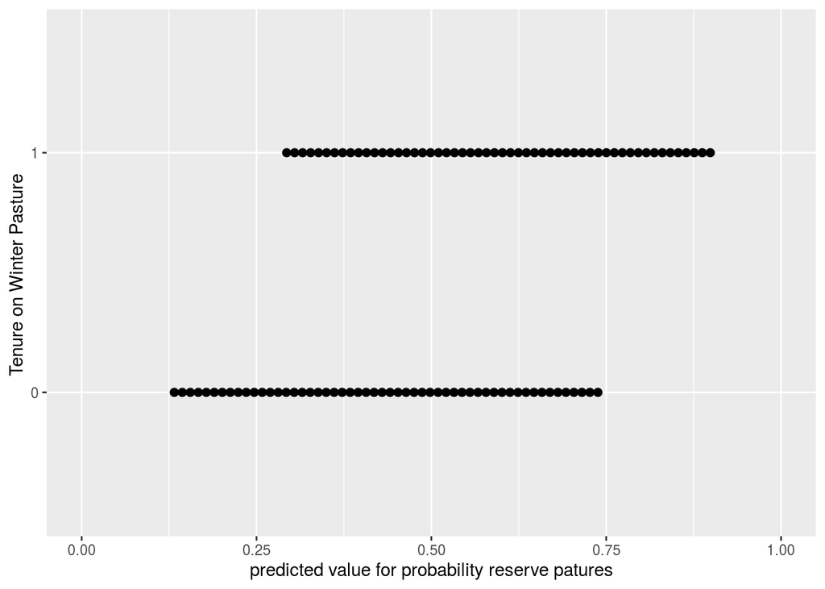

```r
finalW <- glm(ResWint ~ hhTenureWPast + hhTenureWCamp + Rule + cogSC1, family = binomial, data = td)

# start w just one value for each
p_dat <- cbind(expand.grid(hhTenureWPast=c(0,1),hhTenureWCamp=c(0,1),Rule=c(0,1,2), cogSC1=seq(0,2, .25)))

p_dat %<>% mutate_at(c(1:2), funs(factor(.)))
p_dat %<>% mutate_at(3, funs(ordered(.)))





#predict(finalW, p_dat, type="response")
wPred<- predict(finalW, p_dat, type="response")

predDat <- data.frame(p_dat, wPred)


twp<- ggplot(predDat, aes(x= wPred, y=hhTenureWPast))+
  geom_dotplot(binaxis = "y", stackdir = "center")+
  coord_cartesian(xlim = c(0,1))+
  xlab("predicted value for probability reserve patures")+
  ylab("Tenure on Winter Pasture ")
twp
```

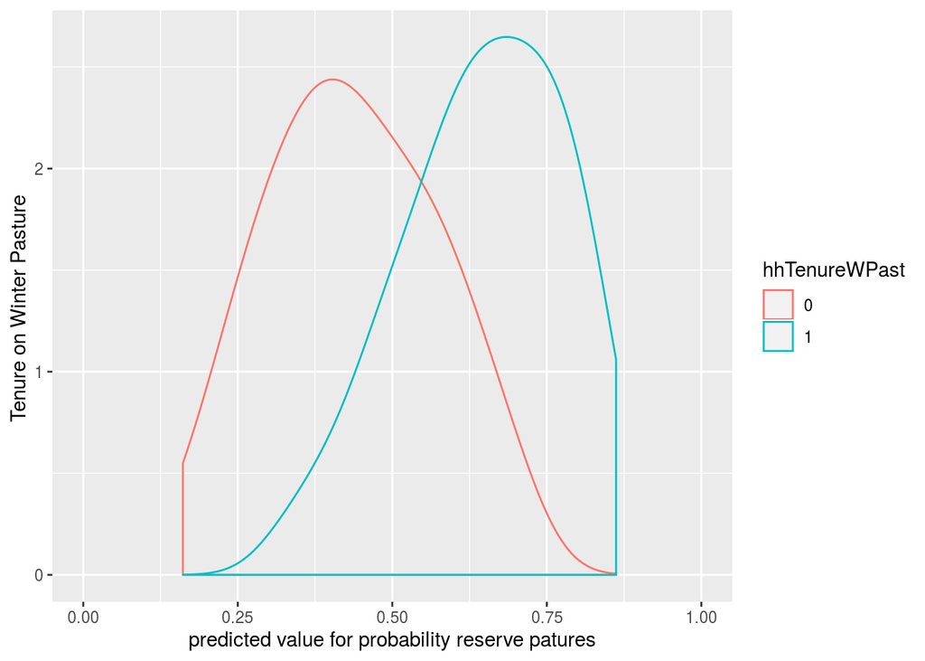

```r
twp<- ggplot(predDat, aes(x= wPred, color=hhTenureWPast))+
  geom_density()+
  coord_cartesian(xlim = c(0,1))+
  xlab("predicted value for probability reserve patures")+
  ylab("Tenure on Winter Pasture ")
twp
```

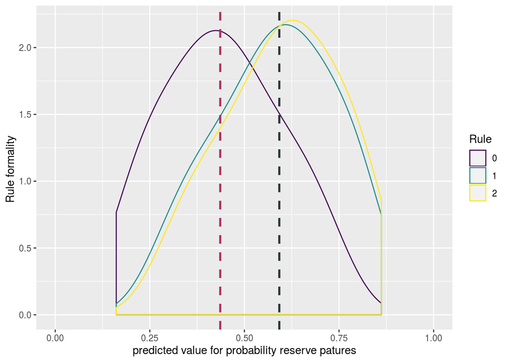

```r
twc<- ggplot(predDat, aes(x= wPred, color=hhTenureWCamp))+
  geom_density()+
  coord_cartesian(xlim = c(0,1))+
  xlab("predicted value for probability reserve patures")+
  ylab("Tenure on Winter Camp ")

rf<- ggplot(predDat, aes(x= wPred, color=Rule))+
  geom_density()+
  coord_cartesian(xlim = c(0,1))+
  xlab("predicted value for probability reserve patures")+
  ylab("Rule formality ")+
    #geom_vline(data= filter(predDat, Rule == 1), aes(xintercept=median(fitted, na.rm=T)),
      #         color="#2C3539", linetype="dashed", size=1)+
  geom_vline(data= filter(predDat, Rule == 1), aes(xintercept=median(wPred, na.rm=T)) ,
               color="#2C3539", linetype="dashed", size=1)+
  geom_vline(data= filter(predDat, Rule == 0), aes(xintercept=median(wPred, na.rm=T)),
               color="Maroon", linetype="dashed", size=1)
rf
```

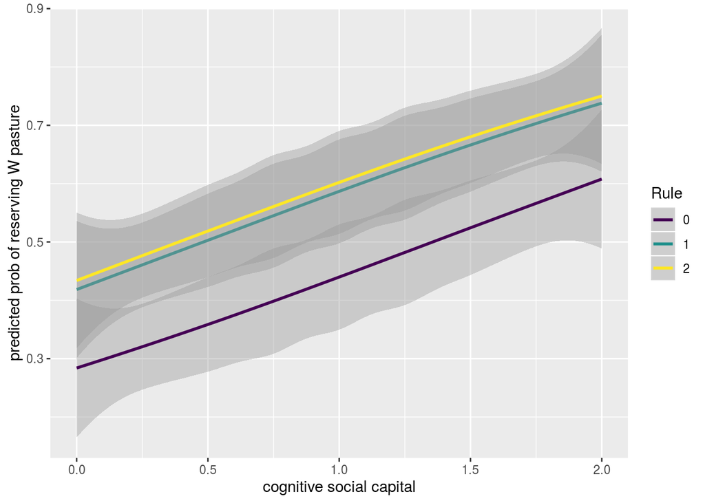

```r
ggplot(predDat, aes(x= cogSC1, y= wPred, color = Rule))+
  geom_smooth()+
  coord_cartesian(xlim = c(0,2))+
  xlab("cognitive social capital")+
  ylab("predicted prob of reserving W pasture") #+
```

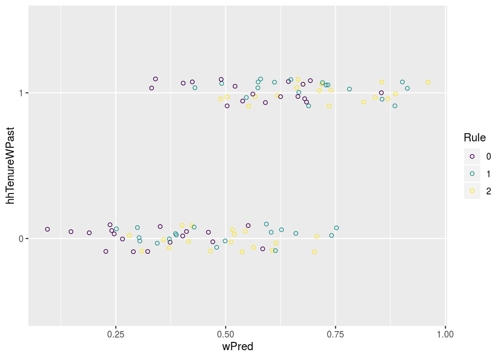

```r
  #facet_wrap(.~hhTenureWPast)

ggplot(predDat, aes(x= wPred, y= hhTenureWPast, color = Rule))+
    geom_point(shape=1,position=position_jitter(width=.1,height=.1))
```

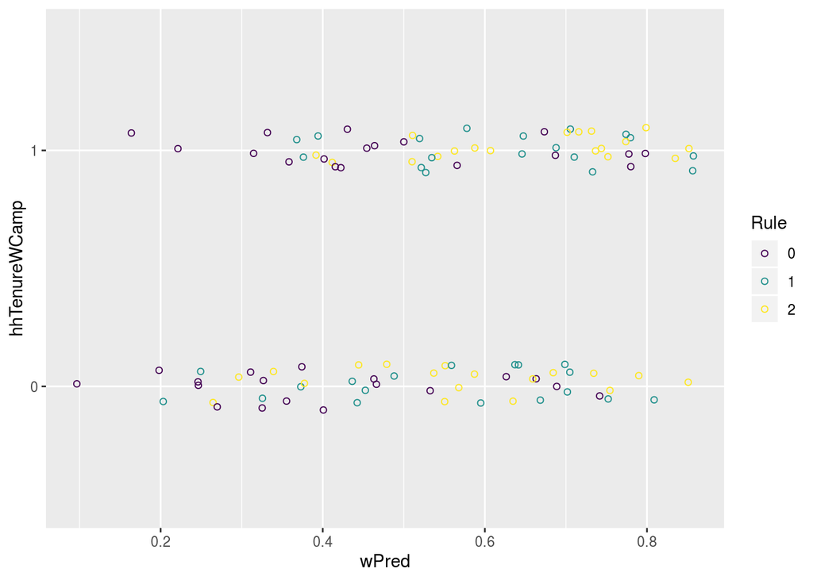

```r
ggplot(predDat, aes(x= wPred, y= hhTenureWCamp, color = Rule))+
    geom_point(shape=1,position=position_jitter(width=.1,height=.1))
```

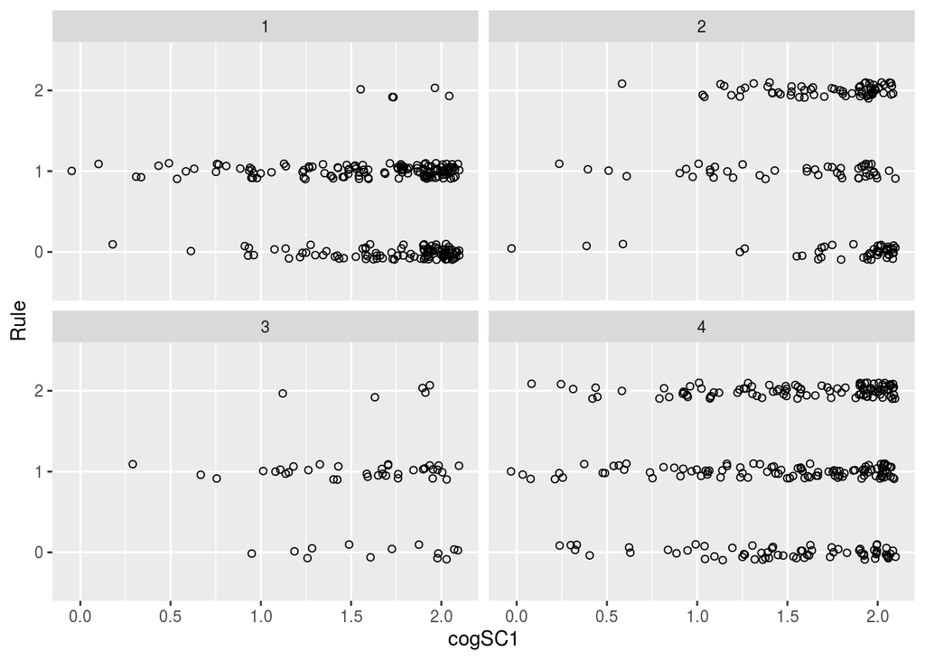

```r
ggplot(td, aes(x= cogSC1, y= Rule))+
    geom_point(shape=1,position=position_jitter(width=.1,height=.1))+
    facet_wrap(.~ez)
```

Looking more at the predicted values:

```r
predDat%>%group_by(hhTenureWPast)%>%
  summarise(pred= median(wPred))
```

```
## # A tibble: 2 x 2
##   hhTenureWPast  pred
##   <fct>         <dbl>
## 1 0             0.431
## 2 1             0.660
```

```r
predDat%>%group_by(hhTenureWCamp)%>%
  summarise(pred= median(wPred))
```

```
## # A tibble: 2 x 2
##   hhTenureWCamp  pred
##   <fct>         <dbl>
## 1 0             0.500
## 2 1             0.598
```

```r
predDat%>%group_by(Rule)%>%
  summarise(pred= median(wPred))
```

```
## # A tibble: 3 x 2
##   Rule   pred
##   <ord> <dbl>
## 1 0     0.436
## 2 1     0.592
## 3 2     0.608
```

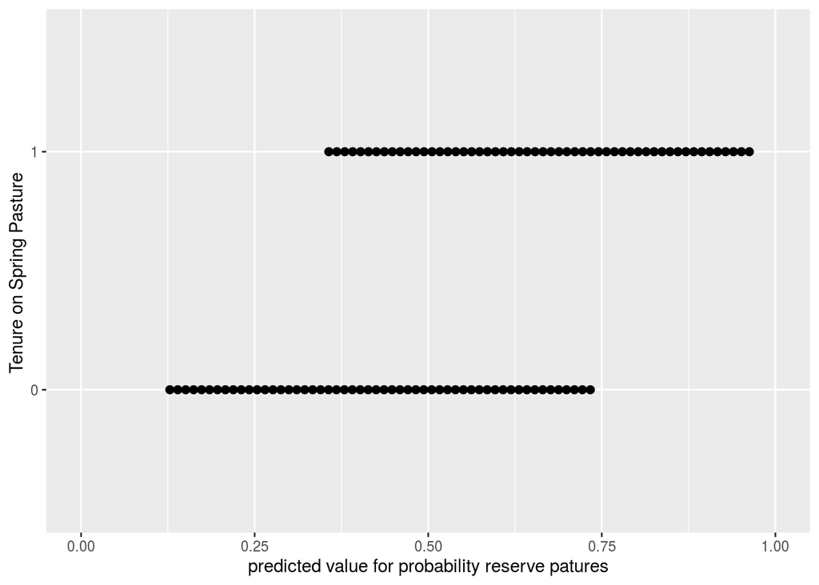

```r
finalS <- glm(ResSpr ~ hhTenureSpPast +cbrmYN + Rule + cogSC1, family = binomial, data = td)

# start w just one value for each
p_dat <- cbind(expand.grid(hhTenureSpPast=c(0,1),cbrmYN=c(0,1),Rule=c(0,1,2), cogSC1=seq(0,2, .25)))

p_dat %<>% mutate_at(c(1:2), funs(factor(.)))
p_dat %<>% mutate_at(3, funs(ordered(.)))





#predict(finalW, p_dat, type="response")
sPred<- predict(finalS, p_dat, type="response")

predDat <- data.frame(p_dat, sPred)


ggplot(predDat, aes(x= sPred, y=hhTenureSpPast))+
  geom_dotplot(binaxis = "y", stackdir = "center")+
  coord_cartesian(xlim = c(0,1))+
  xlab("predicted value for probability reserve patures")+
  ylab("Tenure on Spring Pasture ")
```

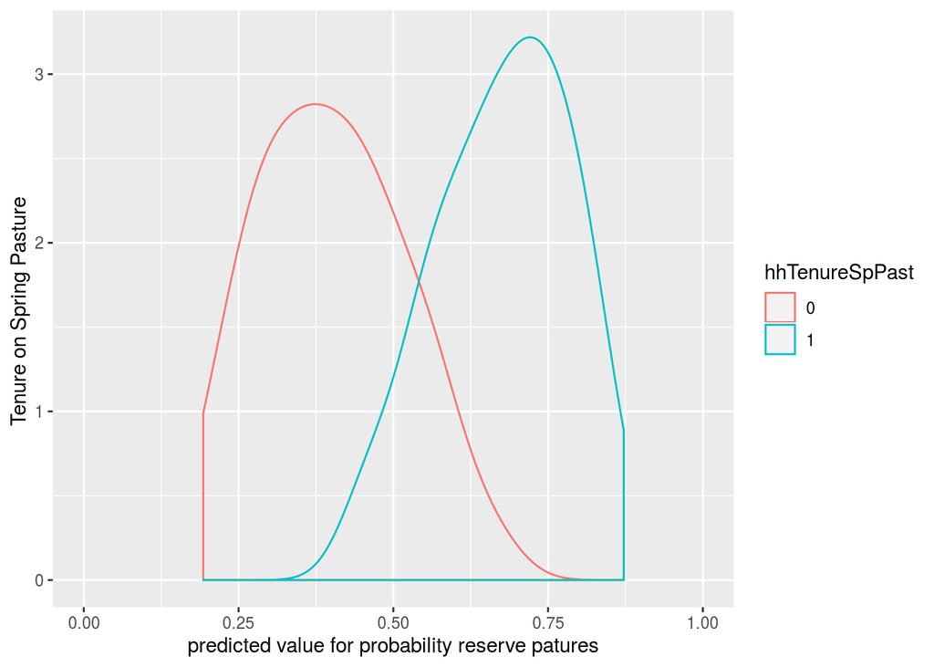

```r
ggplot(predDat, aes(x= sPred, color=hhTenureSpPast))+
  geom_density()+
  coord_cartesian(xlim = c(0,1))+
  xlab("predicted value for probability reserve patures")+
  ylab("Tenure on Spring Pasture ")
```